# Risk Assesment and Management

- **Erdem Sirel**
- **Gizem Yıldırım**

```python
import pandas as pd
pd.set_option('display.max_rows', 500)
import matplotlib.pyplot as plt
import numpy as np
import scipy.stats as stats
import os
```

```python
print("Current version:", pd.__version__, "our_version:", "1.0.5")
```

```
Current version: 1.1.5 our_version: 1.0.5
```

# Phase I

### Import and process data

15 stocks have been chosen randomly from BIST100 index. Weekly price data is imported from investing.com for each stock.

```python
def import_and_prepare_data():
    path = os.path.join(os.getcwd(), "data")
    files = [file for file in os.listdir(path) if file.endswith("csv")]

    data = pd.DataFrame()
    for file in files:
        file_data = pd.read_csv(os.path.join(path,file))
        file_data["Şirket"] = file[: file.find(" ")]
        data = data.append(file_data)
    return data

try:
    data = pd.read_csv("https://raw.githubusercontent.com/ahmetsirel/ETM959_Risk_Project/master/data.csv", sep=';')
except:
    data = import_and_prepare_data()
    data.to_csv("data.csv", sep=';', index=False)
    print("data prepared from raw files")

data.head(5)
```

|  | Tarih | Şimdi | Açılış | Yüksek | Düşük | Hac. | Fark % | Şirket |
| --- | --- | --- | --- | --- | --- | --- | --- | --- |
| 0 | 06.12.2020 | 21,72 | 22,14 | 22,68 | 21,62 | 3,54M | -1,90% | AEFES |
| 1 | 29.11.2020 | 22,14 | 22,46 | 22,82 | 20,94 | 44,57M | -1,51% | AEFES |
| 2 | 22.11.2020 | 22,48 | 22,24 | 23,98 | 21,98 | 12,85M | 1,35% | AEFES |
| 3 | 15.11.2020 | 22,18 | 22,64 | 22,82 | 21,38 | 10,99M | -1,86% | AEFES |
| 4 | 08.11.2020 | 22,60 | 21,64 | 22,90 | 21,20 | 13,11M | 5,81% | AEFES |

```python
# Selected assests
data['Şirket'].unique()
```

```
array(['AEFES', 'AKBNK', 'DEVA', 'DGKLB', 'ECILC', 'ENJSA', 'ENKAI',
       'GOLTS', 'IHLGM', 'SISE', 'THYAO', 'TTKOM', 'TTRAK', 'ULKER',
       'VESTL'], dtype=object)
```

```python
bist_100 = pd.read_csv("BIST 100 Historical Data.csv").head(52)
bist_100["market_return"] = bist_100["Change %"].apply(
    lambda x: round(float(str(x).replace(",", ".").replace("%", "")) / 100, 3)
)
bist_100_returns = bist_100["market_return"]
```

```python
data.Tarih.max(), data.Tarih.min()
```

```
('31.05.2020', '01.03.2020')
```

```python
# Process Columns
data.rename({"Fark %": "return"}, axis=1, inplace=True)
data["Tarih"] = pd.to_datetime(data["Tarih"], dayfirst=True)
data[["Şimdi", "Açılış", "Yüksek", "Düşük"]] = data[
    ["Şimdi", "Açılış", "Yüksek", "Düşük"]
].applymap(lambda x: round(float(str(x).replace(",", ".")), 3))
data["return"] = data["return"].apply(
    lambda x: round(float(str(x).replace(",", ".").replace("%", "")) / 100, 3)
)
data = data[["Şirket", "Tarih", "Şimdi", "return"]]

data.head()
```

|  | Şirket | Tarih | Şimdi | return |
| --- | --- | --- | --- | --- |
| 0 | AEFES | 2020-12-06 | 21.72 | -0.019 |
| 1 | AEFES | 2020-11-29 | 22.14 | -0.015 |
| 2 | AEFES | 2020-11-22 | 22.48 | 0.014 |
| 3 | AEFES | 2020-11-15 | 22.18 | -0.019 |
| 4 | AEFES | 2020-11-08 | 22.60 | 0.058 |

```python
data[data.Şirket == "AEFES"]
```

|  | Şirket | Tarih | Şimdi | return |
| --- | --- | --- | --- | --- |
| 0 | AEFES | 2020-12-06 | 21.72 | -0.019 |
| 1 | AEFES | 2020-11-29 | 22.14 | -0.015 |
| 2 | AEFES | 2020-11-22 | 22.48 | 0.014 |
| 3 | AEFES | 2020-11-15 | 22.18 | -0.019 |
| 4 | AEFES | 2020-11-08 | 22.60 | 0.058 |
| 5 | AEFES | 2020-11-01 | 21.36 | 0.099 |
| 6 | AEFES | 2020-10-25 | 19.43 | -0.153 |
| 7 | AEFES | 2020-10-18 | 22.94 | -0.005 |
| 8 | AEFES | 2020-10-11 | 23.06 | 0.043 |
| 9 | AEFES | 2020-10-04 | 22.10 | 0.057 |
| 10 | AEFES | 2020-09-27 | 20.90 | 0.005 |
| 11 | AEFES | 2020-09-20 | 20.80 | -0.009 |
| 12 | AEFES | 2020-09-13 | 21.00 | 0.019 |
| 13 | AEFES | 2020-09-06 | 20.60 | 0.025 |
| 14 | AEFES | 2020-08-30 | 20.10 | 0.029 |
| 15 | AEFES | 2020-08-23 | 19.54 | -0.013 |
| 16 | AEFES | 2020-08-16 | 19.80 | -0.018 |
| 17 | AEFES | 2020-08-09 | 20.16 | 0.081 |
| 18 | AEFES | 2020-08-02 | 18.65 | -0.037 |
| 19 | AEFES | 2020-07-26 | 19.36 | -0.065 |
| 20 | AEFES | 2020-07-19 | 20.70 | -0.004 |
| 21 | AEFES | 2020-07-12 | 20.78 | -0.065 |
| 22 | AEFES | 2020-07-05 | 22.22 | 0.041 |
| 23 | AEFES | 2020-06-28 | 21.34 | 0.013 |
| 24 | AEFES | 2020-06-21 | 21.06 | 0.022 |
| 25 | AEFES | 2020-06-14 | 20.60 | 0.063 |
| 26 | AEFES | 2020-06-07 | 19.38 | -0.027 |
| 27 | AEFES | 2020-05-31 | 19.91 | 0.074 |
| 28 | AEFES | 2020-05-24 | 18.54 | 0.035 |
| 29 | AEFES | 2020-05-17 | 17.91 | 0.057 |
| 30 | AEFES | 2020-05-10 | 16.94 | -0.006 |
| 31 | AEFES | 2020-05-03 | 17.04 | -0.073 |
| 32 | AEFES | 2020-04-26 | 18.38 | 0.018 |
| 33 | AEFES | 2020-04-19 | 18.05 | -0.020 |
| 34 | AEFES | 2020-04-12 | 18.41 | -0.010 |
| 35 | AEFES | 2020-04-05 | 18.60 | 0.038 |
| 36 | AEFES | 2020-03-29 | 17.91 | 0.029 |
| 37 | AEFES | 2020-03-22 | 17.40 | -0.018 |
| 38 | AEFES | 2020-03-15 | 17.71 | -0.072 |
| 39 | AEFES | 2020-03-08 | 19.08 | -0.178 |
| 40 | AEFES | 2020-03-01 | 23.20 | 0.057 |
| 41 | AEFES | 2020-02-23 | 21.94 | -0.099 |
| 42 | AEFES | 2020-02-16 | 24.36 | -0.010 |
| 43 | AEFES | 2020-02-09 | 24.60 | -0.043 |
| 44 | AEFES | 2020-02-02 | 25.70 | 0.037 |
| 45 | AEFES | 2020-01-26 | 24.78 | -0.047 |
| 46 | AEFES | 2020-01-19 | 26.00 | 0.016 |
| 47 | AEFES | 2020-01-12 | 25.58 | 0.083 |
| 48 | AEFES | 2020-01-05 | 23.62 | 0.023 |
| 49 | AEFES | 2019-12-29 | 23.08 | -0.011 |
| 50 | AEFES | 2019-12-22 | 23.34 | 0.046 |
| 51 | AEFES | 2019-12-15 | 22.32 | 0.013 |

### Interest Rates

Weekly interest rate is calculated as follows, \begin{equation*} weekly\ interest = (annual\ interest / 365) * 7 \end{equation*}

Source:  
https://www.tcmb.gov.tr/wps/wcm/connect/TR/TCMB+TR/Main+Menu/Temel+Faaliyetler/Para+Politikasi/Merkez+Bankasi+Faiz+Oranlari/1+Hafta+Repo

```python
#Interst Rates
interest_rates = pd.DataFrame([["13 09 2019",	16.50],
                                ["25 10 2019",	14.00],
                                ["13 12 2019",	12.00],
                                ["17 01 2020",	11.25],
                                ["20 02 2020",	10.75],
                                ["18 03 2020",	9.75],
                                ["23 04 2020",	8.75],
                                ["22 05 2020",	8.25],
                                ["25 09 2020",	10.25],
                                ["20 11 2020",	15.00]],
                            columns=["date", "rate"])
interest_rates["date"] = pd.to_datetime(interest_rates["date"], dayfirst=True)
interest_rates["rate"] = interest_rates["rate"] / 100
interest_rates = interest_rates.set_index("date")
interest_rates = (interest_rates / 365) * 7 #convert to weekly interest
interest_rates = interest_rates.sort_index(ascending=False)
interest_rates.head()
```

| date | rate |
| --- | --- |
| 2020-11-20 | 0.002877 |
| 2020-09-25 | 0.001966 |
| 2020-05-22 | 0.001582 |
| 2020-04-23 | 0.001678 |
| 2020-03-18 | 0.001870 |

#### Calculate net return by substracting the weekly inflation rate from weekly return

```python
def get_interst(date_):
    return interest_rates[interest_rates.index <=date_].head(1)["rate"].values[0]
data["inflation"] = data.apply(lambda row: get_interst(row["Tarih"]) ,axis=1)
data["net_return"] = data["return"] - data["inflation"]

data = data.sort_values(["Şirket", "Tarih"])
data.head()
```

|  | Şirket | Tarih | Şimdi | return | inflation | net_return |
| --- | --- | --- | --- | --- | --- | --- |
| 51 | AEFES | 2019-12-15 | 22.32 | 0.013 | 0.002301 | 0.010699 |
| 50 | AEFES | 2019-12-22 | 23.34 | 0.046 | 0.002301 | 0.043699 |
| 49 | AEFES | 2019-12-29 | 23.08 | -0.011 | 0.002301 | -0.013301 |
| 48 | AEFES | 2020-01-05 | 23.62 | 0.023 | 0.002301 | 0.020699 |
| 47 | AEFES | 2020-01-12 | 25.58 | 0.083 | 0.002301 | 0.080699 |

### Aggregate data

**Calculate mean & standard deviation for each stock**

```python
#Mean & Standard Deviations for weekly return
data_agg = data.groupby("Şirket").agg({"return": ["mean","std"]})
data_agg.columns = data_agg.columns.get_level_values(1)
mean_returns = data_agg["mean"]

#Mean & Standard Deviations for weekly net return
data_agg_net = data.groupby("Şirket").agg({"net_return": ["mean", "std"]})
data_agg_net.columns = data_agg_net.columns.get_level_values(1)
mean_net_returns = data_agg_net["mean"]
```

### Covariance Calculation

```python
# Cov for weekly return
cov_data = pd.DataFrame()
for company in data["Şirket"].unique():
    current = data[data["Şirket"] == company]["return"].rename(company).reset_index(drop=True)
    cov_data = pd.concat([cov_data, current], axis=1)
cov = cov_data.cov()

# Cov for weekly net return
cov_data_net = pd.DataFrame()
for company in data["Şirket"].unique():
    current_ = data[data["Şirket"] == company]["net_return"].rename(company).reset_index(drop=True)
    cov_data_net = pd.concat([cov_data_net, current_], axis=1)
cov_net = cov_data_net.cov()
```

```python
cov # Cov for weekly return
```

|  | AEFES | AKBNK | DEVA | DGKLB | ECILC | ENJSA | ENKAI | GOLTS | IHLGM | SISE | THYAO | TTKOM | TTRAK | ULKER | VESTL |
| --- | --- | --- | --- | --- | --- | --- | --- | --- | --- | --- | --- | --- | --- | --- | --- |
| AEFES | 0.002998 | 0.002193 | 0.000948 | 0.002333 | 0.000426 | 0.001271 | 0.000660 | 0.002302 | 0.002244 | 0.001525 | 0.002317 | 0.002115 | 0.001739 | 0.001849 | 0.002098 |
| AKBNK | 0.002193 | 0.003918 | 0.000899 | 0.001814 | 0.000825 | 0.001032 | 0.000482 | 0.002027 | 0.002299 | 0.001421 | 0.002904 | 0.002853 | 0.001702 | 0.001897 | 0.002190 |
| DEVA | 0.000948 | 0.000899 | 0.009104 | 0.002961 | 0.006473 | 0.001256 | -0.000021 | 0.002131 | 0.001536 | 0.000334 | 0.001769 | 0.002081 | 0.001887 | 0.001552 | 0.001704 |
| DGKLB | 0.002333 | 0.001814 | 0.002961 | 0.008816 | 0.001931 | 0.001911 | 0.002231 | 0.003657 | 0.004289 | 0.001806 | 0.002962 | 0.002771 | 0.003574 | 0.002002 | 0.003496 |
| ECILC | 0.000426 | 0.000825 | 0.006473 | 0.001931 | 0.009053 | -0.000039 | 0.000131 | 0.001606 | 0.003260 | 0.000316 | 0.001753 | 0.001951 | 0.001333 | 0.001196 | 0.001402 |
| ENJSA | 0.001271 | 0.001032 | 0.001256 | 0.001911 | -0.000039 | 0.001804 | 0.000408 | 0.001776 | 0.001162 | 0.000730 | 0.001078 | 0.001211 | 0.001354 | 0.001019 | 0.001470 |
| ENKAI | 0.000660 | 0.000482 | -0.000021 | 0.002231 | 0.000131 | 0.000408 | 0.001673 | 0.000836 | 0.001005 | 0.000823 | 0.000537 | 0.000548 | 0.001022 | 0.000640 | 0.001022 |
| GOLTS | 0.002302 | 0.002027 | 0.002131 | 0.003657 | 0.001606 | 0.001776 | 0.000836 | 0.006353 | 0.003488 | 0.001553 | 0.002502 | 0.002107 | 0.002989 | 0.002200 | 0.002901 |
| IHLGM | 0.002244 | 0.002299 | 0.001536 | 0.004289 | 0.003260 | 0.001162 | 0.001005 | 0.003488 | 0.008453 | 0.001548 | 0.003038 | 0.002635 | 0.003327 | 0.002759 | 0.003343 |
| SISE | 0.001525 | 0.001421 | 0.000334 | 0.001806 | 0.000316 | 0.000730 | 0.000823 | 0.001553 | 0.001548 | 0.002660 | 0.001674 | 0.001664 | 0.001386 | 0.001249 | 0.001445 |
| THYAO | 0.002317 | 0.002904 | 0.001769 | 0.002962 | 0.001753 | 0.001078 | 0.000537 | 0.002502 | 0.003038 | 0.001674 | 0.004382 | 0.002837 | 0.001838 | 0.001613 | 0.003005 |
| TTKOM | 0.002115 | 0.002853 | 0.002081 | 0.002771 | 0.001951 | 0.001211 | 0.000548 | 0.002107 | 0.002635 | 0.001664 | 0.002837 | 0.003567 | 0.001902 | 0.001899 | 0.002566 |
| TTRAK | 0.001739 | 0.001702 | 0.001887 | 0.003574 | 0.001333 | 0.001354 | 0.001022 | 0.002989 | 0.003327 | 0.001386 | 0.001838 | 0.001902 | 0.004733 | 0.002205 | 0.002503 |
| ULKER | 0.001849 | 0.001897 | 0.001552 | 0.002002 | 0.001196 | 0.001019 | 0.000640 | 0.002200 | 0.002759 | 0.001249 | 0.001613 | 0.001899 | 0.002205 | 0.002933 | 0.002181 |
| VESTL | 0.002098 | 0.002190 | 0.001704 | 0.003496 | 0.001402 | 0.001470 | 0.001022 | 0.002901 | 0.003343 | 0.001445 | 0.003005 | 0.002566 | 0.002503 | 0.002181 | 0.004671 |

```python
cov_net # Cov for weekly net return
```

|  | AEFES | AKBNK | DEVA | DGKLB | ECILC | ENJSA | ENKAI | GOLTS | IHLGM | SISE | THYAO | TTKOM | TTRAK | ULKER | VESTL |
| --- | --- | --- | --- | --- | --- | --- | --- | --- | --- | --- | --- | --- | --- | --- | --- |
| AEFES | 0.003001 | 0.002195 | 0.000951 | 0.002339 | 0.000429 | 0.001272 | 0.000663 | 0.002303 | 0.002246 | 0.001529 | 0.002319 | 0.002116 | 0.001743 | 0.001851 | 0.002099 |
| AKBNK | 0.002195 | 0.003919 | 0.000901 | 0.001818 | 0.000828 | 0.001032 | 0.000484 | 0.002028 | 0.002300 | 0.001424 | 0.002905 | 0.002853 | 0.001705 | 0.001898 | 0.002191 |
| DEVA | 0.000951 | 0.000901 | 0.009107 | 0.002967 | 0.006476 | 0.001256 | -0.000018 | 0.002132 | 0.001538 | 0.000337 | 0.001771 | 0.002082 | 0.001891 | 0.001554 | 0.001705 |
| DGKLB | 0.002339 | 0.001818 | 0.002967 | 0.008825 | 0.001937 | 0.001914 | 0.002238 | 0.003661 | 0.004295 | 0.001813 | 0.002967 | 0.002775 | 0.003581 | 0.002007 | 0.003501 |
| ECILC | 0.000429 | 0.000828 | 0.006476 | 0.001937 | 0.009057 | -0.000038 | 0.000135 | 0.001608 | 0.003262 | 0.000321 | 0.001755 | 0.001953 | 0.001338 | 0.001198 | 0.001404 |
| ENJSA | 0.001272 | 0.001032 | 0.001256 | 0.001914 | -0.000038 | 0.001803 | 0.000409 | 0.001776 | 0.001162 | 0.000731 | 0.001078 | 0.001210 | 0.001356 | 0.001018 | 0.001469 |
| ENKAI | 0.000663 | 0.000484 | -0.000018 | 0.002238 | 0.000135 | 0.000409 | 0.001678 | 0.000839 | 0.001008 | 0.000827 | 0.000540 | 0.000550 | 0.001027 | 0.000643 | 0.001024 |
| GOLTS | 0.002303 | 0.002028 | 0.002132 | 0.003661 | 0.001608 | 0.001776 | 0.000839 | 0.006354 | 0.003489 | 0.001556 | 0.002503 | 0.002108 | 0.002992 | 0.002201 | 0.002902 |
| IHLGM | 0.002246 | 0.002300 | 0.001538 | 0.004295 | 0.003262 | 0.001162 | 0.001008 | 0.003489 | 0.008455 | 0.001551 | 0.003039 | 0.002636 | 0.003330 | 0.002761 | 0.003344 |
| SISE | 0.001529 | 0.001424 | 0.000337 | 0.001813 | 0.000321 | 0.000731 | 0.000827 | 0.001556 | 0.001551 | 0.002665 | 0.001677 | 0.001666 | 0.001391 | 0.001251 | 0.001448 |
| THYAO | 0.002319 | 0.002905 | 0.001771 | 0.002967 | 0.001755 | 0.001078 | 0.000540 | 0.002503 | 0.003039 | 0.001677 | 0.004383 | 0.002837 | 0.001841 | 0.001614 | 0.003006 |
| TTKOM | 0.002116 | 0.002853 | 0.002082 | 0.002775 | 0.001953 | 0.001210 | 0.000550 | 0.002108 | 0.002636 | 0.001666 | 0.002837 | 0.003567 | 0.001905 | 0.001899 | 0.002567 |
| TTRAK | 0.001743 | 0.001705 | 0.001891 | 0.003581 | 0.001338 | 0.001356 | 0.001027 | 0.002992 | 0.003330 | 0.001391 | 0.001841 | 0.001905 | 0.004737 | 0.002208 | 0.002505 |
| ULKER | 0.001851 | 0.001898 | 0.001554 | 0.002007 | 0.001198 | 0.001018 | 0.000643 | 0.002201 | 0.002761 | 0.001251 | 0.001614 | 0.001899 | 0.002208 | 0.002934 | 0.002181 |
| VESTL | 0.002099 | 0.002191 | 0.001705 | 0.003501 | 0.001404 | 0.001469 | 0.001024 | 0.002902 | 0.003344 | 0.001448 | 0.003006 | 0.002567 | 0.002505 | 0.002181 | 0.004672 |

### Calculating the portfolio weights

5.Form two portfolios using different weights,

- one where weights increase proportional to decreasing standard deviations of individual assets and
- one where weights decrease as average returns decrease. Calculate the means and variancesof both portfolios.

  > For this one we had a negative mean return for AKBNK. We took its mean as zero in order to calculate proper weight for portfolio. ("mean_for_p1")

**Calculate the weights of Portfolio 1**

```python
data_agg["mean_for_p1"] = data_agg["mean"].apply(lambda x: max([x, 0]))
data_agg['Portfolio1'] = data_agg["mean_for_p1"] / data_agg["mean_for_p1"].sum()
p1_weights = data_agg['Portfolio1']
```

$$weight_i= \frac{step1_i}{\sum_{k=1}^n step1_k}$$

```python
data_agg["std_for_p2"] =  data_agg["std"].sum() / data_agg["std"]
data_agg['Portfolio2'] =  data_agg["std_for_p2"] / data_agg["std_for_p2"].sum()
p2_weights = data_agg['Portfolio2']

print("Check weights for portfolio 1:", round(p1_weights.sum(),3))
print("Check weights for portfolio 2:",round(p2_weights.sum(),3))
```

```
Check weights for portfolio 1: 1.0
Check weights for portfolio 2: 1.0
```

```python
data_agg.sort_values("std")
```

| Şirket | mean | std | mean_for_p1 | Portfolio1 | std_for_p2 | Portfolio2 |
| --- | --- | --- | --- | --- | --- | --- |
| ENKAI | 0.004135 | 0.040907 | 0.004135 | 0.028667 | 25.072040 | 0.103512 |
| ENJSA | 0.008019 | 0.042478 | 0.008019 | 0.055600 | 24.145054 | 0.099685 |
| SISE | 0.008385 | 0.051576 | 0.008385 | 0.058133 | 19.885674 | 0.082099 |
| ULKER | 0.001673 | 0.054159 | 0.001673 | 0.011600 | 18.937260 | 0.078184 |
| AEFES | 0.001135 | 0.054754 | 0.001135 | 0.007867 | 18.731498 | 0.077334 |
| TTKOM | 0.003731 | 0.059723 | 0.003731 | 0.025867 | 17.173252 | 0.070901 |
| AKBNK | -0.002769 | 0.062592 | 0.000000 | 0.000000 | 16.386080 | 0.067651 |
| THYAO | 0.000115 | 0.066195 | 0.000115 | 0.000800 | 15.494137 | 0.063969 |
| VESTL | 0.012788 | 0.068344 | 0.012788 | 0.088667 | 15.006874 | 0.061957 |
| TTRAK | 0.023596 | 0.068794 | 0.023596 | 0.163600 | 14.908694 | 0.061552 |
| GOLTS | 0.015673 | 0.079709 | 0.015673 | 0.108667 | 12.867241 | 0.053123 |
| IHLGM | 0.011673 | 0.091940 | 0.011673 | 0.080933 | 11.155437 | 0.046056 |
| DGKLB | 0.012962 | 0.093894 | 0.012962 | 0.089867 | 10.923244 | 0.045097 |
| ECILC | 0.016327 | 0.095148 | 0.016327 | 0.113200 | 10.779288 | 0.044503 |
| DEVA | 0.024019 | 0.095417 | 0.024019 | 0.166533 | 10.748932 | 0.044378 |

```python
data_agg.loc["DEVA","std"] / data_agg.loc["ULKER","std"]
```

```
1.761780682013892
```

```python
data_agg.loc["ULKER","Portfolio2"] / data_agg.loc["DEVA","Portfolio2"]
```

```
1.7617806820138924
```

### Calculate Portfolio Parameters

- Mean return of the portfolio (w)
- Variance of the portfolio

### Return

**Portfolio 1**

##### Mean & Variance Calculation

```python
# multiply weights
def mul_weight(row_column):

    return np.multiply(row_column, p1_weights)
# Multiply relavant stock weights for each covariance to calculated portfolio covariance.
cov_p1 = cov.apply(mul_weight, axis=1).apply(mul_weight, axis=0)
```

```python
p1_parameters = pd.DataFrame.from_dict({"Mean return of the portfolio (w)": [np.matmul(p1_weights, mean_returns)],
                                        "Variance of the portfolio": [cov_p1.sum().sum()]}).rename({0:"Portfolio 1"})
p1_parameters
```

|  | Mean return of the portfolio (w) | Variance of the portfolio |
| --- | --- | --- |
| Portfolio 1 | 0.015832 | 0.002735 |

**Portfolio 2**

```python
# multiply weights
def mul_weight2(row_column):

    return np.multiply(row_column, p2_weights)
# Multiply relavant stock weights for each covariance to calculated portfolio covariance.
cov_p2 = cov.apply(mul_weight2, axis=1).apply(mul_weight2, axis=0)
```

```python
p2_parameters = pd.DataFrame.from_dict({"Mean return of the portfolio (w)": [np.matmul(p2_weights, mean_returns)],
                                        "Variance of the portfolio": [cov_p2.sum().sum()]}).rename({0:"Portfolio 2"})
p2_parameters
```

|  | Mean return of the portfolio (w) | Variance of the portfolio |
| --- | --- | --- |
| Portfolio 2 | 0.008211 | 0.001797 |

### Portfolio Parameters for return (without inflation)

```python
portfolio_parameters = p1_parameters.append(p2_parameters)
portfolio_parameters
```

|  | Mean return of the portfolio (w) | Variance of the portfolio |
| --- | --- | --- |
| Portfolio 1 | 0.015832 | 0.002735 |
| Portfolio 2 | 0.008211 | 0.001797 |

### Net Return

#### Portfolio 1

```python
# multiply weights
def mul_weight(row_column):

    return np.multiply(row_column, p1_weights)

cov_p1_net = cov_net.apply(mul_weight, axis=1).apply(mul_weight, axis=0)
```

```python
p1_parameters_net = pd.DataFrame.from_dict({"Mean net return of the portfolio (w)": [np.matmul(p1_weights, mean_net_returns)],
                                        "Variance of the portfolio": [cov_p1_net.sum().sum()]}).rename({0:"Portfolio 1"})
```

#### Portfolio 2

```python
# multiply weights
def mul_weight2(row_column):

    return np.multiply(row_column, p2_weights)

cov_p2_net = cov.apply(mul_weight2, axis=1).apply(mul_weight2, axis=0)
```

```python
p2_parameters_net = pd.DataFrame.from_dict({"Mean net return of the portfolio (w)": [np.matmul(p2_weights, mean_net_returns)],
                                        "Variance of the portfolio": [cov_p2_net.sum().sum()]}).rename({0:"Portfolio 2"})
```

### Portfolio Parameters for return (with inflation)

```python
portfolio_parameters_net = p1_parameters_net.append(p2_parameters_net)
portfolio_parameters_net
```

|  | Mean net return of the portfolio (w) | Variance of the portfolio |
| --- | --- | --- |
| Portfolio 1 | 0.013920 | 0.002738 |
| Portfolio 2 | 0.006299 | 0.001797 |

### 6.1 Probability of Gaining Positive Return

Assuming the average weekly return of a portfolio is normally distributed with the parameter values you have collected  
calculate the **probability of gaining a positive return**  
and the probability of gaining a return above the inflation rate (rate banks loan money). You need weekly rates.

```python
portfolio_parameters
```

|  | Mean return of the portfolio (w) | Variance of the portfolio |
| --- | --- | --- |
| Portfolio 1 | 0.015832 | 0.002735 |
| Portfolio 2 | 0.008211 | 0.001797 |

```python
portfolio_parameters["z-value"] = (
    (0 - portfolio_parameters["Mean return of the portfolio (w)"]) /
        np.sqrt(portfolio_parameters[ "Variance of the portfolio"])
                                    )
portfolio_parameters["p-value"] = portfolio_parameters["z-value"].apply(lambda z: stats.norm.sf(abs(z)))
portfolio_parameters["probability"] = 1- portfolio_parameters["p-value"]
```

```python
portfolio_parameters
```

|  | Mean return of the portfolio (w) | Variance of the portfolio | z-value | p-value | probability |
| --- | --- | --- | --- | --- | --- |
| Portfolio 1 | 0.015832 | 0.002735 | -0.302729 | 0.381048 | 0.618952 |
| Portfolio 2 | 0.008211 | 0.001797 | -0.193712 | 0.423201 | 0.576799 |

#### Result

Probability of gaining a positive return:  
Portfolio1: 61.8%  
Portfolio2: 57.6%

### 6.2 Probability of Gaining Return Above Inflation

Assuming the average weekly return of a portfolio is normally distributed with the parameter values you have collected  
calculate the probability of gaining a positive return  
and the **probability of gaining a return above the inflation rate** (rate banks loan money). You need weekly rates.

```python
portfolio_parameters_net
```

|  | Mean net return of the portfolio (w) | Variance of the portfolio |
| --- | --- | --- |
| Portfolio 1 | 0.013920 | 0.002738 |
| Portfolio 2 | 0.006299 | 0.001797 |

```python
portfolio_parameters_net["z-value"] = (
    (0 - portfolio_parameters_net["Mean net return of the portfolio (w)"]) /
         np.sqrt(portfolio_parameters_net[ "Variance of the portfolio"])
                                    )
portfolio_parameters_net["p-value"] = portfolio_parameters_net["z-value"].apply(lambda z: stats.norm.sf(abs(z)))
portfolio_parameters_net["probability"] = 1- portfolio_parameters_net["p-value"]
```

```python
portfolio_parameters_net
```

|  | Mean net return of the portfolio (w) | Variance of the portfolio | z-value | p-value | probability |
| --- | --- | --- | --- | --- | --- |
| Portfolio 1 | 0.013920 | 0.002738 | -0.266021 | 0.395112 | 0.604888 |
| Portfolio 2 | 0.006299 | 0.001797 | -0.148597 | 0.440936 | 0.559064 |

#### Result

Probability of gaining a return above the inflation rate:  
Portfolio1: 60.4%  
Portfolio2: 55.9%

# Phase II

**Q1.Find the weights using the Markowitz model for different target return rates. Analyze the shorting and no shorting cases. (Use Excelsolver or equivalent for quadratic optimization)**

```python
import scipy.optimize as optimize
```

```python
def portfolio_parameters(weights, returns, risk_free_rate=0):

    '''
    We can gather the portfolio performance metrics for a specific set of weights.
    This function will be important because we'll want to pass it to an optmization
    function to get the portfolio with the best desired characteristics.

    Note: Sharpe ratio here uses a risk-free short rate of 0.

    Paramaters:
    -----------
        weights: array,
            asset weights in the portfolio.
        returns: dataframe
            a dataframe of returns for each asset in the trial portfolio

    Returns:
    --------
        dict of portfolio statistics - mean return, volatility, standard dev.
    '''

    # Convert to array in case list was passed instead.
    weights = np.array(weights)
    port_return = np.sum(returns.mean() * weights)
    port_var = np.dot(weights.T, np.dot(returns.cov(), weights))
    sharpe = (port_return - risk_free_rate) / np.sqrt(port_var)

    return {'return': port_return,
            'variance': port_var,
            'std': np.sqrt(port_var),
           'sharpe': sharpe}
```

```python
returns = cov_data
```

```python
# Objective Function
def minimize_volatility(weights):
    return portfolio_parameters(weights, returns)['std']
```

##### Shorting Allowed

```python
num_assets = len(returns.columns)
target_returns = [0.01, 0.015, 0.02, 0.025]

portfolio_list_shorting_allowed=pd.DataFrame()
for target_return in target_returns:
    constraints = ({'type':'eq','fun': lambda weights: portfolio_parameters(weights, returns)['return']-target_return},
                   {'type':'eq','fun': lambda weights: np.sum(weights)-1})
    #bounds = tuple((0,1) for x in range(num_assets))
    initializer = num_assets * [1./num_assets,]

    optimal_variance=optimize.minimize(fun=minimize_volatility,
                                     x0=initializer,
                                     method = 'SLSQP',
                                     #bounds = bounds,
                                     constraints = constraints)

    weights_ = optimal_variance['x'].round(4)
    weights_df = pd.DataFrame(weights_, index=returns.columns).T.rename({0:target_return},axis=0)
    portfolio_parameters_df = pd.DataFrame.from_dict(portfolio_parameters(weights_, returns), orient='index').T.rename({0:target_return},axis=0)
    portfolio_summary = pd.concat([weights_df,portfolio_parameters_df], axis=1)
    portfolio_list_shorting_allowed = portfolio_list_shorting_allowed.append(portfolio_summary)
```

##### Shorting not Allowed

```python
num_assets = len(returns.columns)
target_returns = [0.01, 0.015, 0.02, 0.025]

portfolio_list_shorting_not_allowed=pd.DataFrame()
for target_return in target_returns:
    constraints = ({'type':'eq','fun': lambda weights: portfolio_parameters(weights, returns)['return']-target_return},
                   {'type':'eq','fun': lambda weights: np.sum(weights)-1})
    bounds = tuple((0,1) for x in range(num_assets))
    initializer = num_assets * [1./num_assets,]

    optimal_variance=optimize.minimize(fun=minimize_volatility,
                                     x0=initializer,
                                     method = 'SLSQP',
                                     bounds = bounds,
                                     constraints = constraints)

    weights_ = optimal_variance['x'].round(4)
    weights_df = pd.DataFrame(weights_, index=returns.columns).T.rename({0:target_return},axis=0)
    portfolio_parameters_df = pd.DataFrame.from_dict(portfolio_parameters(weights_, returns), orient='index').T.rename({0:target_return},axis=0)
    portfolio_summary = pd.concat([weights_df,portfolio_parameters_df], axis=1)
    portfolio_list_shorting_not_allowed = portfolio_list_shorting_not_allowed.append(portfolio_summary)
```

```python
portfolio_list_shorting_allowed
```

|  | AEFES | AKBNK | DEVA | DGKLB | ECILC | ENJSA | ENKAI | GOLTS | IHLGM | SISE | THYAO | TTKOM | TTRAK | ULKER | VESTL | return | variance | std | sharpe |
| --- | --- | --- | --- | --- | --- | --- | --- | --- | --- | --- | --- | --- | --- | --- | --- | --- | --- | --- | --- |
| 0.010 | -0.0202 | 0.0020 | 0.0518 | -0.2012 | 0.1041 | 0.4492 | 0.4608 | -0.0241 | 0.0138 | 0.1708 | 0.0019 | -0.0567 | 0.1339 | -0.1009 | 0.0147 | 0.009998 | 0.000826 | 0.028746 | 0.347794 |
| 0.015 | -0.0406 | -0.0167 | 0.1059 | -0.2227 | 0.0917 | 0.4356 | 0.4178 | -0.0045 | 0.0346 | 0.2473 | -0.0805 | -0.0625 | 0.2412 | -0.2379 | 0.0912 | 0.014999 | 0.001131 | 0.033624 | 0.446085 |
| 0.020 | -0.0597 | -0.0310 | 0.1610 | -0.2436 | 0.0788 | 0.4222 | 0.3751 | 0.0159 | 0.0580 | 0.3205 | -0.1652 | -0.0689 | 0.3479 | -0.3779 | 0.1669 | 0.020000 | 0.001609 | 0.040113 | 0.498587 |
| 0.025 | -0.0714 | -0.0358 | 0.2178 | -0.2607 | 0.0666 | 0.4033 | 0.3407 | 0.0301 | 0.0790 | 0.3962 | -0.2632 | -0.0804 | 0.4550 | -0.5238 | 0.2466 | 0.025000 | 0.002261 | 0.047547 | 0.525795 |

```python
portfolio_list_shorting_not_allowed
```

|  | AEFES | AKBNK | DEVA | DGKLB | ECILC | ENJSA | ENKAI | GOLTS | IHLGM | SISE | THYAO | TTKOM | TTRAK | ULKER | VESTL | return | variance | std | sharpe |
| --- | --- | --- | --- | --- | --- | --- | --- | --- | --- | --- | --- | --- | --- | --- | --- | --- | --- | --- | --- |
| 0.010 | 0.0 | 0.0 | 0.0399 | 0.0 | 0.0966 | 0.3314 | 0.2969 | 0.0 | 0.0 | 0.1295 | 0.0 | 0.0 | 0.1056 | 0.0 | 0.0 | 0.009998 | 0.001087 | 0.032972 | 0.303234 |
| 0.015 | 0.0 | 0.0 | 0.1421 | 0.0 | 0.0482 | 0.1887 | 0.1654 | 0.0 | 0.0 | 0.1411 | 0.0 | 0.0 | 0.3145 | 0.0 | 0.0 | 0.015001 | 0.001712 | 0.041376 | 0.362555 |
| 0.020 | 0.0 | 0.0 | 0.2437 | 0.0 | 0.0000 | 0.0541 | 0.0369 | 0.0 | 0.0 | 0.1406 | 0.0 | 0.0 | 0.5247 | 0.0 | 0.0 | 0.020000 | 0.002784 | 0.052766 | 0.379022 |
| 0.025 | 0.0 | 0.0 | 1.0000 | 0.0 | 0.0000 | 0.0000 | 0.0000 | 0.0 | 0.0 | 0.0000 | 0.0 | 0.0 | 0.0000 | 0.0 | 0.0 | 0.024019 | 0.009104 | 0.095417 | 0.251729 |

**Q2.Using the results generate the efficient frontier for your portfolio.**

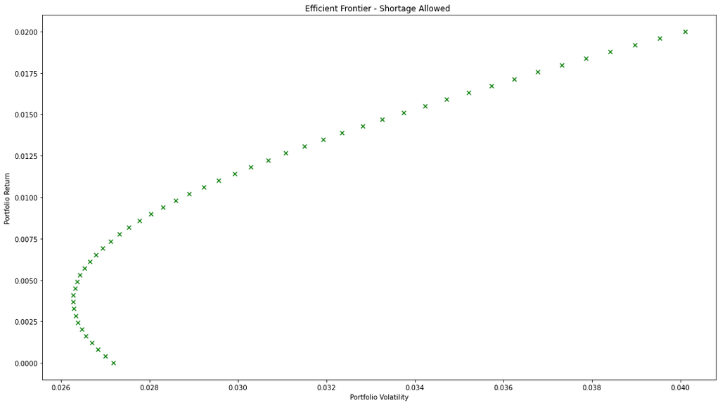

```python
num_assets = len(returns.columns)
target_returns = np.linspace(0,0.02, 50)

portfolio_list_min_var=pd.DataFrame()
for target_return in target_returns:
    constraints = ({'type':'eq','fun': lambda weights: portfolio_parameters(weights, returns)['return']-target_return},
                   {'type':'eq','fun': lambda weights: np.sum(weights)-1})
    #bounds = tuple((0,1) for x in range(num_assets))
    initializer = num_assets * [1./num_assets,]

    optimal_variance=optimize.minimize(fun=minimize_volatility,
                                     x0=initializer,
                                     method = 'SLSQP',
                                     #bounds = bounds,
                                     constraints = constraints)

    weights_ = optimal_variance['x'].round(4)
    weights_df = pd.DataFrame(weights_, index=returns.columns).T.rename({0:target_return},axis=0)
    portfolio_parameters_df = pd.DataFrame.from_dict(portfolio_parameters(weights_, returns), orient='index').T.rename({0:target_return},axis=0)
    portfolio_summary = pd.concat([weights_df,portfolio_parameters_df], axis=1)
    portfolio_list_min_var = portfolio_list_min_var.append(portfolio_summary)


plt.figure(figsize=(18,10))

plt.scatter(portfolio_list_min_var["std"],
            portfolio_list_min_var["return"],
            c='forestgreen',
            marker = 'x')
plt.title('Efficient Frontier - Shortage Allowed ')
plt.xlabel('Portfolio Volatility')
plt.ylabel('Portfolio Return')
```

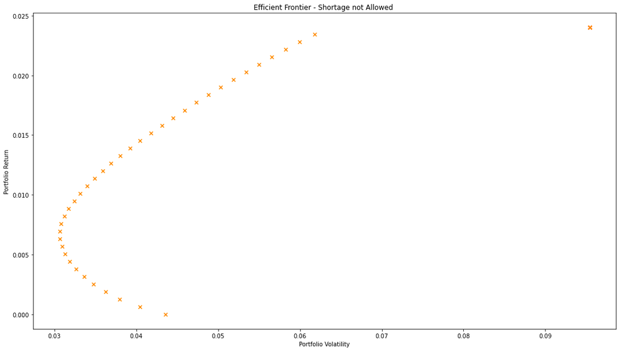

```python
num_assets = len(returns.columns)
target_returns = np.linspace(0,0.05, 80)

portfolio_list_min_var=pd.DataFrame()
for target_return in target_returns:
    constraints = ({'type':'eq','fun': lambda weights: portfolio_parameters(weights, returns)['return']-target_return},
                   {'type':'eq','fun': lambda weights: np.sum(weights)-1})
    bounds = tuple((0,1) for weights in range(num_assets))
    initializer = num_assets * [1./num_assets,]

    optimal_variance=optimize.minimize(fun=minimize_volatility,
                                     x0=initializer,
                                     method = 'SLSQP',
                                     bounds = bounds,
                                     constraints = constraints)

    weights_ = optimal_variance['x'].round(4)
    weights_df = pd.DataFrame(weights_, index=returns.columns).T.rename({0:target_return},axis=0)
    portfolio_parameters_df = pd.DataFrame.from_dict(portfolio_parameters(weights_, returns), orient='index').T.rename({0:target_return},axis=0)
    portfolio_summary = pd.concat([weights_df,portfolio_parameters_df], axis=1)
    portfolio_list_min_var = portfolio_list_min_var.append(portfolio_summary)

plt.figure(figsize=(18,10))

plt.scatter(portfolio_list_min_var["std"],
            portfolio_list_min_var["return"],
            c='darkorange',
            marker = 'x')
plt.title('Efficient Frontier - Shortage not Allowed ')
plt.xlabel('Portfolio Volatility')
plt.ylabel('Portfolio Return')
```

```python
portfolio_list_min_var.sort_values("return", ascending=False).iloc[0]["return"]
```

```
0.02401923076923076
```

**Q3 .Add a risk-free rate using the current Central Bank rates for loans and apply the one fund theorem.**

###### Method 1

```python
risk_free_rate=interest_rates.mean()
risk_free_rate
```

```
rate    0.002234
dtype: float64
```

```python
inverse_cov = pd.DataFrame(np.linalg.inv(returns.cov()),columns=returns.columns, index=returns.columns)
inverse_cov
```

|  | AEFES | AKBNK | DEVA | DGKLB | ECILC | ENJSA | ENKAI | GOLTS | IHLGM | SISE | THYAO | TTKOM | TTRAK | ULKER | VESTL |
| --- | --- | --- | --- | --- | --- | --- | --- | --- | --- | --- | --- | --- | --- | --- | --- |
| AEFES | 939.667385 | -98.686102 | 16.644785 | -15.597500 | 51.397687 | -224.374621 | -41.915391 | -61.648313 | -5.585027 | -113.535001 | -208.819221 | -80.117724 | 37.665491 | -260.468650 | 51.411961 |
| AKBNK | -98.686102 | 886.012772 | 57.584558 | 116.191643 | 44.538934 | -11.522197 | -125.423685 | -29.075746 | 19.561932 | 125.350412 | -334.715179 | -528.181384 | -39.389781 | -190.902425 | 119.743522 |
| DEVA | 16.644785 | 57.584558 | 378.978044 | -93.760356 | -284.066735 | -253.177243 | 154.724310 | 9.511472 | 139.088316 | 46.480865 | -47.934128 | -6.190655 | -34.945804 | -133.136710 | 23.847038 |
| DGKLB | -15.597500 | 116.191643 | -93.760356 | 330.830733 | 69.820768 | -48.248488 | -338.707888 | -36.841013 | -80.850072 | 45.031616 | -80.952150 | -143.407939 | -68.401064 | 96.323419 | -3.185464 |
| ECILC | 51.397687 | 44.538934 | -284.066735 | 69.820768 | 376.658362 | 273.147818 | -116.225101 | -36.687219 | -144.550500 | 18.856694 | -18.957859 | -150.623461 | 20.833533 | 57.965486 | 10.938953 |
| ENJSA | -224.374621 | -11.522197 | -253.177243 | -48.248488 | 273.147818 | 1243.632427 | 13.232000 | -144.265354 | -38.409870 | 3.922260 | 147.001414 | -167.885869 | -47.566279 | 79.726569 | -139.805274 |
| ENKAI | -41.915391 | -125.423685 | 154.724310 | -338.707888 | -116.225101 | 13.232000 | 1164.794373 | 49.744579 | 77.446493 | -246.249518 | 180.222197 | 224.338233 | -29.900149 | -70.289934 | -149.924136 |
| GOLTS | -61.648313 | -29.075746 | 9.511472 | -36.841013 | -36.687219 | -144.265354 | 49.744579 | 308.940383 | -19.199800 | -38.057771 | -26.541830 | 97.052015 | -62.600802 | -35.871184 | -41.364554 |
| IHLGM | -5.585027 | 19.561932 | 139.088316 | -80.850072 | -144.550500 | -38.409870 | 77.446493 | -19.199800 | 284.858129 | 21.822266 | -65.366872 | 21.825302 | -58.965625 | -150.066093 | -25.331442 |
| SISE | -113.535001 | 125.350412 | 46.480865 | 45.031616 | 18.856694 | 3.922260 | -246.249518 | -38.057771 | 21.822266 | 693.806519 | -148.741315 | -257.737523 | -46.642635 | -86.792385 | 84.725747 |
| THYAO | -208.819221 | -334.715179 | -47.934128 | -80.952150 | -18.957859 | 147.001414 | 180.222197 | -26.541830 | -65.366872 | -148.741315 | 820.237984 | -62.814875 | 42.478817 | 254.066523 | -276.561762 |
| TTKOM | -80.117724 | -528.181384 | -6.190655 | -143.407939 | -150.623461 | -167.885869 | 224.338233 | 97.052015 | 21.825302 | -257.737523 | -62.814875 | 1200.535317 | 26.215583 | -65.261006 | -156.771245 |
| TTRAK | 37.665491 | -39.389781 | -34.945804 | -68.401064 | 20.833533 | -47.566279 | -29.900149 | -62.600802 | -58.965625 | -46.642635 | 42.478817 | 26.215583 | 445.715954 | -144.067835 | -37.025244 |
| ULKER | -260.468650 | -190.902425 | -133.136710 | 96.323419 | 57.965486 | 79.726569 | -70.289934 | -35.871184 | -150.066093 | -86.792385 | 254.066523 | -65.261006 | -144.067835 | 947.086737 | -180.197513 |
| VESTL | 51.411961 | 119.743522 | 23.847038 | -3.185464 | 10.938953 | -139.805274 | -149.924136 | -41.364554 | -25.331442 | 84.725747 | -276.561762 | -156.771245 | -37.025244 | -180.197513 | 587.711587 |

```python
right_handside = pd.DataFrame([i-risk_free_rate for i in returns.mean()])
v_values = pd.DataFrame(np.dot(inverse_cov,right_handside['rate']),index=inverse_cov.columns)
v_values.columns=['v_val']
v_values['weights']=v_values['v_val']/v_values['v_val'].sum()
v_values
```

|  | v_val | weights |
| --- | --- | --- |
| AEFES | -0.761085 | -0.347757 |
| AKBNK | -0.487945 | -0.222953 |
| DEVA | 3.168676 | 1.447840 |
| DGKLB | -1.569893 | -0.717320 |
| ECILC | -0.450080 | -0.205652 |
| ENJSA | -0.036015 | -0.016456 |
| ENKAI | -1.279705 | -0.584726 |
| GOLTS | 0.952483 | 0.435211 |
| IHLGM | 1.252197 | 0.572157 |
| SISE | 4.651464 | 2.125359 |
| THYAO | -4.957060 | -2.264993 |
| TTKOM | -0.813124 | -0.371535 |
| TTRAK | 6.098149 | 2.786382 |
| ULKER | -8.060167 | -3.682873 |
| VESTL | 4.480659 | 2.047314 |

```python
one_fund_mean_1 = np.sum(returns.mean()*v_values['weights'])
one_fund_var_1 = np.dot(v_values['weights'].T, (np.dot(returns.cov(),v_values['weights'])))
print('mean and variance according to one fund with method 1:',round(one_fund_mean_1,4),'&',round(one_fund_var_1,4))
```

```
mean and variance according to one fund with method 1: 0.1352 & 0.0608
```

##### Method 2

```python
def portfolio_parameters_net(weights, returns):
    weights = np.array(weights)
    port_return = np.sum(right_handside['rate'] * weights)
    port_var = np.dot(weights.T, np.dot(returns.cov(), weights))

    return {'return': port_return, 'variance': port_var, 'std': np.sqrt(port_var)}

# Objective Function
def minimize_volatility(weights):
    return -portfolio_parameters_net(weights, returns)['return']/portfolio_parameters_net(weights, returns)['std']
```

```python
num_assets = len(returns.columns)
constraints = ({'type':'eq','fun': lambda weights: np.sum(weights)-1})

initializer = num_assets * [1./num_assets,]

optimal_variance=optimize.minimize(fun=minimize_volatility,
                                 x0=initializer,
                                 method = 'SLSQP',
                                 #bounds = bounds,
                                 constraints = constraints)

print(optimal_variance)

weights_ = optimal_variance['x'].round(4)
portfolio_parameters_net(weights_, returns)
```

```
     fun: -0.5395137379961898
     jac: array([ 4.69908118e-05, -1.04404986e-04,  2.54236162e-04, -6.07967377e-06,
        2.97144055e-04, -9.39369202e-05,  1.03905797e-04, -2.63452530e-05,
        4.83095646e-05,  1.31055713e-05, -2.48849392e-06, -1.20222569e-04,
       -1.51991844e-04, -7.59661198e-05, -1.06334686e-04])
 message: 'Optimization terminated successfully'
    nfev: 768
     nit: 48
    njev: 48
  status: 0
 success: True
       x: array([-0.33294389, -0.22195285,  1.44421754, -0.71512981, -0.20373791,
       -0.02407462, -0.56520319,  0.43252927,  0.57189449,  2.11118805,
       -2.24559486, -0.37825461,  2.7590292 , -3.6606309 ,  2.0286641 ])
```

```
{'return': 0.13197349957850368,
 'variance': 0.05983681722868956,
 'std': 0.2446156520517229}
```

```python
question_3=pd.DataFrame()
question_3['method_1']=v_values['weights']
question_3['method_2']=optimal_variance['x']
question_3
```

|  | method_1 | method_2 |
| --- | --- | --- |
| AEFES | -0.347757 | -0.332944 |
| AKBNK | -0.222953 | -0.221953 |
| DEVA | 1.447840 | 1.444218 |
| DGKLB | -0.717320 | -0.715130 |
| ECILC | -0.205652 | -0.203738 |
| ENJSA | -0.016456 | -0.024075 |
| ENKAI | -0.584726 | -0.565203 |
| GOLTS | 0.435211 | 0.432529 |
| IHLGM | 0.572157 | 0.571894 |
| SISE | 2.125359 | 2.111188 |
| THYAO | -2.264993 | -2.245595 |
| TTKOM | -0.371535 | -0.378255 |
| TTRAK | 2.786382 | 2.759029 |
| ULKER | -3.682873 | -3.660631 |
| VESTL | 2.047314 | 2.028664 |

```python
one_fund_mean_method_2 = np.sum(returns.mean()*question_3['method_2'])
one_fund_var_method_2 = np.dot(question_3['method_2'].T, (np.dot(returns.cov(),question_3['method_2'])))
print('mean and variance according to one fund with method_2:',round(one_fund_mean_method_2,4),'&',round(one_fund_var_method_2,4))
```

```
mean and variance according to one fund with method_2: 0.1342 & 0.0598
```

**Q4.Assuming the weekly return of a portfolio is normally distributed with the average and standard deviation you have calculated for the optimal weights calculate the probability of gaining return above the inflation (risk free return) rate. Compare the result with the previous portion of the assignment. Comment.**

```python
one_fund=pd.DataFrame()
one_fund["z-value"] = (risk_free_rate - one_fund_mean_1) / np.sqrt(one_fund_var_1)
one_fund["p-value"] = one_fund["z-value"].apply(lambda z: stats.norm.sf(abs(z)))
one_fund["probability"] = 1- one_fund["p-value"]
one_fund
```

|  | z-value | p-value | probability |
| --- | --- | --- | --- |
| rate | -0.539518 | 0.294765 | 0.705235 |

# Phase 3

## 1) Assume your portfolio is the market portfolio; draw the capital market line and the security market line. Calculate the price of risk.

```python
market_portfolio = portfolio_list_min_var.sort_values("return", ascending=False).reset_index()
market_portfolio = market_portfolio.loc[50]
market_portfolio
```

```
index       0.018354
AEFES       0.000000
AKBNK       0.000000
DEVA        0.205300
DGKLB       0.000000
ECILC       0.016300
ENJSA       0.101400
ENKAI       0.070000
GOLTS       0.000000
IHLGM       0.000000
SISE        0.149200
THYAO       0.000000
TTKOM       0.000000
TTRAK       0.457900
ULKER       0.000000
VESTL       0.000000
return      0.018356
variance    0.002382
std         0.048806
sharpe      0.376090
Name: 50, dtype: float64
```

```python
market_return = market_portfolio["return"]
market_std = market_portfolio["std"]
risk_free_rate_of_return = interest_rates.mean()[0]
risk_free_rate_of_return
```

```
0.0022342465753424656
```

```python
market_return,market_std, risk_free_rate_of_return,
```

```
(0.01835551346153846, 0.04880620187300223, 0.0022342465753424656)
```

```python
price_of_risk = (market_return - risk_free_rate_of_return)/market_std
price_of_risk
```

```
0.330311851107465
```

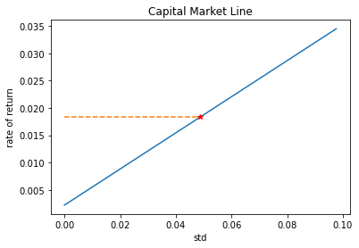

```python
plt.plot([0, market_std, market_std*2 ], [risk_free_rate_of_return, market_return, (2*market_return-risk_free_rate_of_return) ])
plt.plot([0,market_std], [market_return,market_return], "--")
plt.plot([market_std],[market_return], "r*")
plt.title("Capital Market Line")
plt.xlabel("std")
plt.ylabel("rate of return")
plt.show()
```

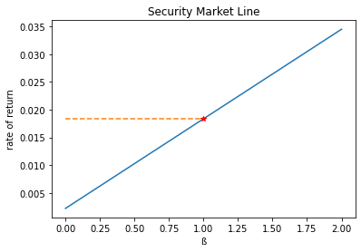

```python
plt.plot([0,1, 2],[risk_free_rate_of_return, market_return, (2*market_return-risk_free_rate_of_return)])
plt.plot([0,1], [market_return,market_return], "--")
plt.plot([1],[market_return], "r*")
plt.title("Security Market Line")
plt.xlabel("ß")
plt.ylabel("rate of return")
plt.show()
```

## 2) Apply the CAPM model to your portfolio, find the beta values for your assets in your portfolio, and find the capital market line and the security market line. Comment on them.

- https://www.investing.com/indices/ise-100
- 1-Year Change: 25.87%

```python
market_return = bist_100_returns.mean()
print(f"market_return: {market_return}")
```

```
market_return: 0.004942307692307694
```

```python
asset_returns = returns.agg(("mean", "std"))
asset_returns = asset_returns.T
asset_returns
```

|  | mean | std |
| --- | --- | --- |
| AEFES | 0.001135 | 0.054754 |
| AKBNK | -0.002769 | 0.062592 |
| DEVA | 0.024019 | 0.095417 |
| DGKLB | 0.012962 | 0.093894 |
| ECILC | 0.016327 | 0.095148 |
| ENJSA | 0.008019 | 0.042478 |
| ENKAI | 0.004135 | 0.040907 |
| GOLTS | 0.015673 | 0.079709 |
| IHLGM | 0.011673 | 0.091940 |
| SISE | 0.008385 | 0.051576 |
| THYAO | 0.000115 | 0.066195 |
| TTKOM | 0.003731 | 0.059723 |
| TTRAK | 0.023596 | 0.068794 |
| ULKER | 0.001673 | 0.054159 |
| VESTL | 0.012788 | 0.068344 |

```python
returns
```

|  | AEFES | AKBNK | DEVA | DGKLB | ECILC | ENJSA | ENKAI | GOLTS | IHLGM | SISE | THYAO | TTKOM | TTRAK | ULKER | VESTL |
| --- | --- | --- | --- | --- | --- | --- | --- | --- | --- | --- | --- | --- | --- | --- | --- |
| 0 | 0.013 | 0.014 | -0.031 | 0.012 | -0.003 | 0.003 | 0.017 | -0.036 | 0.115 | 0.046 | -0.004 | -0.004 | -0.009 | 0.009 | 0.043 |
| 1 | 0.046 | 0.011 | 0.072 | -0.075 | -0.003 | -0.018 | -0.115 | 0.038 | 0.124 | 0.011 | 0.014 | 0.029 | 0.079 | 0.059 | -0.021 |
| 2 | -0.011 | -0.034 | -0.018 | 0.050 | -0.003 | -0.032 | 0.021 | -0.033 | 0.028 | -0.004 | 0.022 | -0.012 | -0.006 | -0.024 | 0.015 |
| 3 | 0.023 | 0.094 | 0.005 | -0.006 | 0.068 | 0.077 | 0.003 | 0.013 | 0.000 | 0.008 | 0.010 | 0.078 | 0.087 | 0.102 | 0.066 |
| 4 | 0.083 | 0.015 | 0.043 | 0.060 | 0.013 | -0.019 | 0.014 | 0.057 | 0.018 | 0.013 | 0.044 | 0.020 | 0.003 | -0.010 | 0.015 |
| 5 | 0.016 | -0.007 | 0.151 | 0.181 | 0.055 | 0.031 | 0.025 | 0.008 | 0.026 | -0.037 | -0.033 | 0.006 | -0.011 | 0.012 | -0.012 |
| 6 | -0.047 | -0.057 | 0.060 | 0.014 | -0.002 | 0.019 | 0.055 | 0.001 | -0.026 | 0.073 | -0.059 | -0.037 | 0.031 | -0.066 | -0.020 |
| 7 | 0.037 | 0.021 | 0.014 | 0.085 | -0.005 | 0.028 | -0.033 | -0.006 | 0.079 | -0.005 | 0.058 | 0.013 | 0.037 | 0.025 | 0.134 |
| 8 | -0.043 | -0.039 | -0.008 | -0.017 | 0.036 | 0.024 | -0.015 | -0.053 | 0.122 | -0.011 | 0.029 | 0.051 | -0.041 | -0.019 | 0.072 |
| 9 | -0.010 | -0.051 | -0.050 | -0.053 | -0.049 | -0.035 | -0.013 | -0.075 | -0.109 | -0.051 | -0.025 | 0.050 | 0.023 | -0.045 | -0.030 |
| 10 | -0.099 | -0.121 | -0.130 | -0.159 | -0.068 | -0.055 | -0.030 | -0.124 | -0.016 | -0.069 | -0.191 | -0.131 | -0.034 | -0.086 | -0.146 |
| 11 | 0.057 | 0.078 | 0.031 | 0.072 | 0.008 | 0.032 | 0.054 | -0.010 | 0.074 | 0.000 | -0.052 | 0.036 | -0.005 | 0.123 | -0.056 |
| 12 | -0.178 | -0.115 | -0.006 | -0.368 | 0.054 | -0.111 | -0.130 | -0.194 | -0.269 | -0.166 | -0.179 | -0.192 | -0.178 | -0.129 | -0.251 |
| 13 | -0.072 | -0.144 | -0.112 | -0.131 | -0.182 | -0.052 | -0.037 | -0.095 | -0.211 | -0.035 | -0.127 | -0.036 | -0.167 | -0.049 | -0.037 |
| 14 | -0.018 | 0.002 | 0.314 | 0.085 | 0.530 | -0.084 | 0.002 | 0.043 | 0.200 | 0.015 | 0.110 | 0.081 | -0.021 | 0.013 | 0.060 |
| 15 | 0.029 | -0.020 | -0.103 | 0.104 | -0.122 | 0.034 | 0.048 | 0.097 | 0.111 | 0.058 | 0.008 | -0.011 | 0.062 | 0.057 | 0.010 |
| 16 | 0.038 | 0.129 | 0.010 | 0.110 | 0.007 | -0.016 | 0.091 | 0.090 | 0.050 | 0.103 | 0.097 | 0.085 | 0.143 | 0.033 | 0.078 |
| 17 | -0.010 | -0.054 | 0.073 | 0.035 | 0.018 | 0.008 | 0.024 | 0.009 | 0.000 | 0.065 | 0.073 | -0.033 | 0.049 | 0.082 | 0.027 |
| 18 | -0.020 | -0.009 | 0.330 | 0.034 | 0.055 | 0.083 | -0.028 | 0.043 | 0.000 | 0.055 | -0.024 | 0.040 | 0.081 | 0.061 | 0.034 |
| 19 | 0.018 | 0.026 | 0.122 | 0.093 | -0.008 | 0.116 | -0.040 | 0.182 | 0.019 | -0.064 | 0.041 | 0.042 | 0.050 | -0.021 | 0.132 |
| 20 | -0.073 | -0.056 | -0.111 | 0.085 | -0.061 | -0.031 | 0.026 | -0.062 | 0.028 | -0.010 | -0.008 | -0.068 | -0.016 | -0.054 | -0.034 |
| 21 | -0.006 | -0.022 | 0.312 | 0.039 | 0.285 | 0.051 | -0.003 | 0.037 | 0.045 | -0.002 | -0.002 | 0.086 | 0.100 | 0.035 | 0.027 |
| 22 | 0.057 | 0.015 | -0.061 | 0.005 | -0.012 | 0.027 | -0.008 | 0.037 | 0.043 | 0.050 | 0.060 | 0.015 | -0.016 | 0.020 | 0.039 |
| 23 | 0.035 | 0.031 | 0.058 | 0.037 | -0.014 | 0.009 | 0.001 | -0.021 | 0.025 | -0.038 | 0.124 | -0.020 | 0.003 | -0.003 | 0.040 |
| 24 | 0.074 | 0.040 | -0.023 | 0.036 | 0.007 | 0.028 | 0.004 | 0.067 | 0.065 | 0.056 | 0.009 | 0.035 | 0.043 | -0.017 | -0.037 |
| 25 | -0.027 | -0.019 | -0.014 | 0.005 | 0.034 | -0.006 | 0.011 | 0.021 | 0.191 | -0.020 | 0.003 | -0.021 | 0.083 | 0.012 | 0.106 |
| 26 | 0.063 | 0.031 | 0.066 | 0.020 | 0.015 | -0.006 | 0.059 | 0.017 | -0.038 | 0.034 | -0.019 | 0.033 | 0.007 | 0.063 | 0.077 |
| 27 | 0.022 | -0.017 | -0.013 | 0.214 | 0.035 | 0.007 | 0.042 | 0.014 | 0.067 | 0.050 | -0.004 | 0.040 | 0.130 | -0.038 | -0.007 |
| 28 | 0.013 | 0.002 | 0.042 | 0.124 | 0.044 | 0.037 | 0.011 | 0.086 | 0.050 | 0.055 | -0.044 | 0.009 | 0.045 | 0.032 | 0.015 |
| 29 | 0.041 | -0.025 | -0.033 | -0.132 | -0.030 | -0.001 | -0.040 | -0.002 | -0.018 | 0.066 | -0.008 | -0.032 | 0.093 | 0.023 | -0.002 |
| 30 | -0.065 | 0.012 | 0.053 | 0.172 | 0.026 | 0.017 | 0.057 | 0.146 | 0.097 | 0.013 | 0.009 | 0.053 | 0.117 | 0.052 | 0.071 |
| 31 | -0.004 | -0.007 | 0.008 | -0.080 | -0.017 | -0.035 | 0.022 | 0.065 | -0.022 | 0.042 | -0.016 | -0.034 | 0.008 | -0.003 | 0.027 |
| 32 | -0.065 | -0.093 | 0.036 | 0.065 | 0.005 | -0.019 | 0.006 | -0.080 | -0.040 | -0.107 | -0.089 | -0.099 | 0.070 | -0.020 | -0.026 |
| 33 | -0.037 | -0.092 | 0.007 | 0.025 | -0.063 | 0.026 | -0.015 | -0.146 | -0.147 | 0.045 | 0.006 | -0.039 | -0.106 | -0.152 | -0.102 |
| 34 | 0.081 | 0.036 | 0.067 | -0.052 | -0.027 | 0.014 | 0.009 | 0.090 | 0.028 | -0.008 | 0.036 | 0.001 | -0.013 | 0.015 | 0.024 |
| 35 | -0.018 | 0.028 | -0.130 | -0.088 | 0.002 | -0.017 | 0.026 | 0.014 | 0.047 | 0.037 | -0.003 | 0.020 | -0.066 | 0.016 | 0.057 |
| 36 | -0.013 | -0.012 | -0.024 | 0.068 | 0.002 | -0.041 | -0.020 | 0.053 | -0.051 | -0.010 | -0.010 | -0.024 | 0.051 | 0.016 | 0.055 |
| 37 | 0.029 | -0.018 | -0.028 | -0.004 | 0.064 | 0.007 | 0.015 | 0.060 | -0.054 | 0.019 | -0.042 | -0.001 | -0.017 | -0.046 | 0.019 |
| 38 | 0.025 | 0.000 | 0.019 | 0.008 | 0.078 | 0.042 | 0.011 | 0.188 | 0.107 | -0.005 | 0.037 | 0.001 | 0.095 | 0.014 | -0.044 |
| 39 | 0.019 | -0.010 | 0.014 | -0.019 | 0.000 | 0.020 | 0.081 | -0.030 | -0.071 | 0.026 | -0.026 | -0.011 | -0.007 | 0.013 | -0.004 |
| 40 | -0.009 | 0.047 | -0.030 | -0.054 | 0.011 | -0.005 | -0.062 | -0.020 | 0.014 | 0.106 | -0.018 | 0.038 | -0.025 | 0.009 | -0.038 |
| 41 | 0.005 | 0.010 | -0.012 | 0.000 | 0.006 | 0.021 | 0.019 | -0.023 | -0.014 | -0.004 | 0.015 | 0.007 | 0.032 | 0.014 | 0.023 |
| 42 | 0.057 | 0.000 | 0.066 | 0.061 | 0.000 | 0.054 | 0.039 | 0.040 | 0.083 | -0.019 | 0.013 | 0.013 | 0.063 | 0.014 | 0.019 |
| 43 | 0.043 | 0.010 | 0.023 | 0.030 | 0.036 | 0.012 | 0.006 | -0.014 | 0.115 | -0.019 | -0.019 | 0.036 | 0.117 | 0.042 | 0.051 |
| 44 | -0.005 | -0.027 | 0.133 | 0.063 | 0.026 | 0.007 | -0.006 | 0.046 | -0.218 | 0.004 | -0.017 | -0.020 | -0.002 | -0.042 | -0.010 |
| 45 | -0.153 | -0.057 | -0.061 | -0.122 | -0.081 | -0.054 | 0.008 | -0.133 | -0.110 | -0.100 | -0.130 | -0.128 | -0.054 | -0.138 | -0.089 |
| 46 | 0.099 | 0.052 | 0.088 | 0.071 | 0.085 | 0.093 | 0.054 | 0.023 | 0.033 | 0.077 | 0.076 | 0.056 | 0.152 | 0.070 | 0.158 |
| 47 | 0.058 | 0.257 | 0.016 | -0.007 | -0.034 | 0.030 | -0.042 | -0.017 | 0.008 | 0.032 | 0.184 | 0.180 | -0.001 | 0.008 | 0.045 |
| 48 | -0.019 | 0.030 | 0.002 | -0.007 | 0.000 | -0.018 | -0.010 | 0.101 | -0.008 | 0.031 | 0.033 | 0.011 | 0.111 | 0.031 | -0.003 |
| 49 | 0.014 | -0.019 | 0.007 | 0.011 | 0.004 | 0.066 | -0.022 | 0.197 | 0.040 | -0.020 | 0.004 | -0.053 | -0.023 | -0.011 | 0.034 |
| 50 | -0.015 | -0.031 | -0.007 | -0.004 | 0.013 | 0.038 | 0.013 | 0.088 | 0.000 | 0.017 | 0.020 | 0.027 | 0.032 | -0.012 | -0.016 |
| 51 | -0.019 | 0.021 | 0.012 | -0.022 | 0.011 | 0.011 | 0.010 | 0.018 | -0.023 | 0.033 | 0.020 | 0.008 | 0.048 | -0.003 | 0.077 |

```python
cov_with_market = pd.concat([cov_data, bist_100_returns], axis=1).cov()["market_return"].rename("cov")
cov_with_market
```

```
AEFES            0.000076
AKBNK            0.000195
DEVA            -0.000552
DGKLB            0.000246
ECILC           -0.000007
ENJSA           -0.000379
ENKAI           -0.000215
GOLTS           -0.000318
IHLGM            0.000179
SISE             0.000079
THYAO            0.000072
TTKOM            0.000246
TTRAK           -0.000149
ULKER            0.000075
VESTL            0.000058
market_return    0.001630
Name: cov, dtype: float64
```

```python
ß = cov_with_market / cov_with_market.market_return
```

```python
ß
```

```
AEFES            0.046673
AKBNK            0.119368
DEVA            -0.338900
DGKLB            0.150686
ECILC           -0.004343
ENJSA           -0.232377
ENKAI           -0.132083
GOLTS           -0.195058
IHLGM            0.110072
SISE             0.048330
THYAO            0.044242
TTKOM            0.151232
TTRAK           -0.091378
ULKER            0.046031
VESTL            0.035339
market_return    1.000000
Name: cov, dtype: float64
```

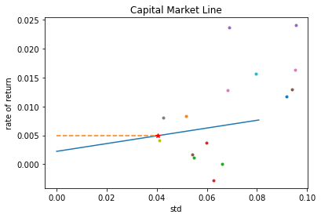

```python
plt.plot([0, bist_100_returns.std(), bist_100_returns.std()*2 ], [risk_free_rate_of_return, market_return, (2*market_return-risk_free_rate_of_return) ])
plt.plot([0,bist_100_returns.std()], [market_return,market_return], "--")
plt.plot([bist_100_returns.std()],[market_return], "r*")
plt.plot([asset_returns["std"]],[asset_returns["mean"]], ".")
plt.title("Capital Market Line")
plt.xlabel("std")
plt.ylabel("rate of return")
plt.show()
```

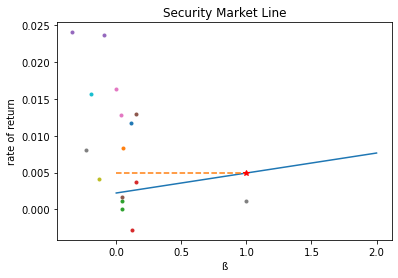

```python
plt.plot([0,1, 2],[risk_free_rate_of_return, market_return, (2*market_return-risk_free_rate_of_return)])
plt.plot([0,1], [market_return,market_return], "--")
plt.plot([1],[market_return], "r*")
plt.plot([ß],[asset_returns["mean"]], ".")
plt.title("Security Market Line")
plt.xlabel("ß")
plt.ylabel("rate of return")
plt.show()
```

### 3) Abandon the assumption and evaluate the performance of your portfolio using the market index of your choice. Calculate the Sharpe and Jensen index values for your portfolio and the individual assets in your portfolio. Calculate their beta values.

```python
portfolio_return = market_portfolio["return"]
portfolio_std = market_portfolio["std"]
risk_free_rate_of_return = interest_rates.mean()[0]
risk_free_rate_of_return
```

```
0.0022342465753424656
```

```python
ß = ß[0:15]
```

```python
ß = ß.rename("ß")
ß
```

```
AEFES    0.046673
AKBNK    0.119368
DEVA    -0.338900
DGKLB    0.150686
ECILC   -0.004343
ENJSA   -0.232377
ENKAI   -0.132083
GOLTS   -0.195058
IHLGM    0.110072
SISE     0.048330
THYAO    0.044242
TTKOM    0.151232
TTRAK   -0.091378
ULKER    0.046031
VESTL    0.035339
Name: ß, dtype: float64
```

```python
portfolio_weights = market_portfolio[1:16]
portfolio_weights
```

```
AEFES    0.0000
AKBNK    0.0000
DEVA     0.2053
DGKLB    0.0000
ECILC    0.0163
ENJSA    0.1014
ENKAI    0.0700
GOLTS    0.0000
IHLGM    0.0000
SISE     0.1492
THYAO    0.0000
TTKOM    0.0000
TTRAK    0.4579
ULKER    0.0000
VESTL    0.0000
Name: 50, dtype: float64
```

```python
ß_portfolio = np.sum(ß * portfolio_weights)
```

```python
ß_portfolio
```

```
-0.13708679226380946
```

#### Portfolio Jensen Index & Sharpe Ratio

```python
jensen_portfolio =  (portfolio_return - risk_free_rate_of_return) - ß_portfolio*(market_return - risk_free_rate_of_return)
```

```python
jensen_portfolio
```

```
0.016492506297975107
```

```python
sharpe_portfolio = (portfolio_return - risk_free_rate_of_return) / portfolio_std
```

```python
sharpe_portfolio
```

```
0.330311851107465
```

#### Individual Jensen Index & Sharpe Ratio

```python
asset_parameters = data_agg[["mean", "std"]]
```

```python
asset_parameters = pd.concat([asset_parameters,ß], axis=1)
```

```python
asset_parameters
```

| Şirket | mean | std | ß |
| --- | --- | --- | --- |
| AEFES | 0.001135 | 0.054754 | 0.046673 |
| AKBNK | -0.002769 | 0.062592 | 0.119368 |
| DEVA | 0.024019 | 0.095417 | -0.338900 |
| DGKLB | 0.012962 | 0.093894 | 0.150686 |
| ECILC | 0.016327 | 0.095148 | -0.004343 |
| ENJSA | 0.008019 | 0.042478 | -0.232377 |
| ENKAI | 0.004135 | 0.040907 | -0.132083 |
| GOLTS | 0.015673 | 0.079709 | -0.195058 |
| IHLGM | 0.011673 | 0.091940 | 0.110072 |
| SISE | 0.008385 | 0.051576 | 0.048330 |
| THYAO | 0.000115 | 0.066195 | 0.044242 |
| TTKOM | 0.003731 | 0.059723 | 0.151232 |
| TTRAK | 0.023596 | 0.068794 | -0.091378 |
| ULKER | 0.001673 | 0.054159 | 0.046031 |
| VESTL | 0.012788 | 0.068344 | 0.035339 |

```python
asset_parameters["Jensen"] = (asset_parameters["mean"] - risk_free_rate_of_return) - asset_parameters["ß"]*(market_return - risk_free_rate_of_return)
```

```python
asset_parameters["Sharpe"] = (asset_parameters["mean"] - risk_free_rate_of_return) / asset_parameters["std"]
```

```python
asset_parameters
```

| Şirket | mean | std | ß | Jensen | Sharpe |
| --- | --- | --- | --- | --- | --- |
| AEFES | 0.001135 | 0.054754 | 0.046673 | -0.001226 | -0.020083 |
| AKBNK | -0.002769 | 0.062592 | 0.119368 | -0.005327 | -0.079938 |
| DEVA | 0.024019 | 0.095417 | -0.338900 | 0.022703 | 0.228313 |
| DGKLB | 0.012962 | 0.093894 | 0.150686 | 0.010319 | 0.114248 |
| ECILC | 0.016327 | 0.095148 | -0.004343 | 0.014104 | 0.148113 |
| ENJSA | 0.008019 | 0.042478 | -0.232377 | 0.006414 | 0.136188 |
| ENKAI | 0.004135 | 0.040907 | -0.132083 | 0.002258 | 0.046455 |
| GOLTS | 0.015673 | 0.079709 | -0.195058 | 0.013967 | 0.168599 |
| IHLGM | 0.011673 | 0.091940 | 0.110072 | 0.009141 | 0.102663 |
| SISE | 0.008385 | 0.051576 | 0.048330 | 0.006019 | 0.119248 |
| THYAO | 0.000115 | 0.066195 | 0.044242 | -0.002239 | -0.032009 |
| TTKOM | 0.003731 | 0.059723 | 0.151232 | 0.001087 | 0.025058 |
| TTRAK | 0.023596 | 0.068794 | -0.091378 | 0.021609 | 0.310519 |
| ULKER | 0.001673 | 0.054159 | 0.046031 | -0.000686 | -0.010361 |
| VESTL | 0.012788 | 0.068344 | 0.035339 | 0.010459 | 0.154428 |